# motifStack Vignette

Jianhong Ou, Michael Brodsky, Lihua Julie Zhu

24 October 2023

Abstract

The motifStack package is designed for graphic representation of multiple motifs with different similarity scores. It works with both DNA/RNA sequence motif, affinity logo and amino acid sequence motif. In addition, it provides the flexibility for users to customize the graphic parameters such as the font type and symbol colors.

# Introduction

A sequence logo, based on information theory, has been widely used as a graphical representation of sequence conservation (aka motif) in multiple amino acid or nucleic acid sequences. Sequence motif represents conserved characteristics such as DNA binding sites, where transcription factors bind, and catalytic sites in enzymes. Although many tools, such as seqlogo<sup>1</sup>, have been developed to create sequence motif and to represent it as individual sequence logo, software tools for depicting the relationship among multiple sequence motifs are still lacking. We developed a flexible and powerful open-source R/Bioconductor package, **motifStack**, for visualization of the alignment of multiple sequence motifs.

# Import matrix

The `importMatrix` function is used to import motifs from files or convert `XMatrix`/`XMatrixList` object into **motifStack** compatable format.

## convert motifs from `XMatrixList`

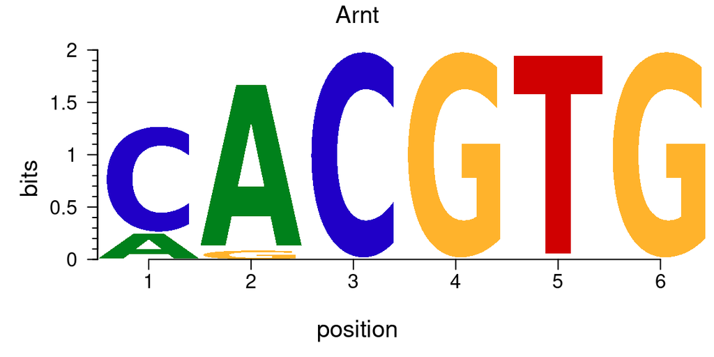

import data from PFMatrixList

```r
library(motifStack)
library(JASPAR2020)
motifs <- importMatrix(getMatrixSet(JASPAR2020,
                                    list(species="Mus musculus")))
plot(motifs[[1]])
```

## import motifs from files

The supported formats are “meme”, “transfac”, “jaspar”, “scpd”, “cisbp”, and “psam”.

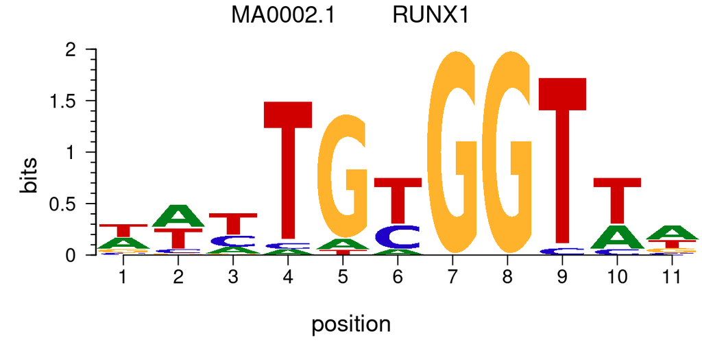

import data from file

```r
RUNX1 <- importMatrix(system.file("extdata", "MA0002.1.jaspar",
                                  package = "motifStack",
                                  mustWork = TRUE))[[1]]
plot(RUNX1)
```

# Examples of using motifStack

## plot a DNA sequence logo with different fonts and colors

Users can select different fonts and colors to draw the sequence logo.

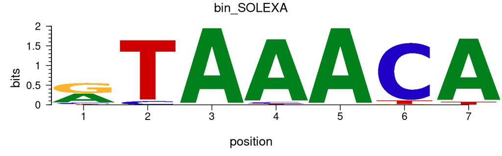

Plot a DNA sequence logo with different fonts and colors

```r
library(motifStack)
pcm <- read.table(file.path(find.package("motifStack"),
                            "extdata", "bin_SOLEXA.pcm"))
pcm <- pcm[,3:ncol(pcm)]
rownames(pcm) <- c("A","C","G","T")
motif <- new("pcm", mat=as.matrix(pcm), name="bin_SOLEXA")
##pfm object
#motif <- pcm2pfm(pcm)
#motif <- new("pfm", mat=motif, name="bin_SOLEXA")
plot(motif)
```

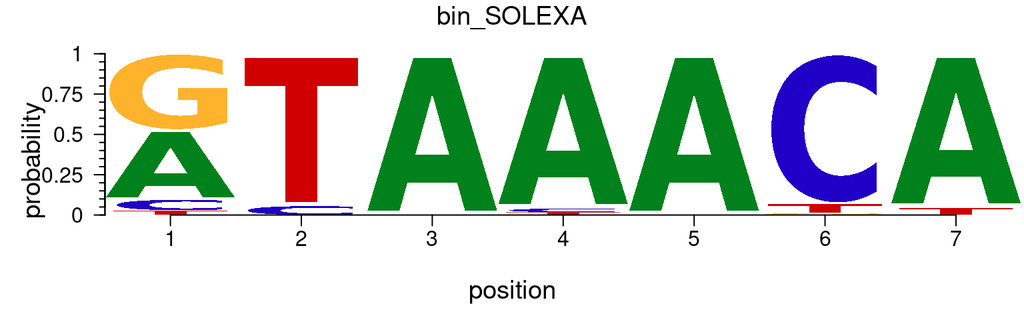

Plot a DNA sequence logo with different fonts and colors

```r
#plot the logo with same height
plot(motif, ic.scale=FALSE, ylab="probability")
```

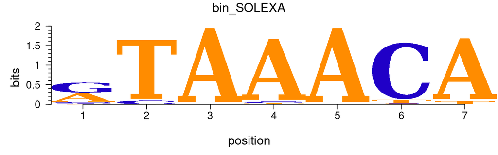

Plot a DNA sequence logo with different fonts and colors

```r
#try a different font and a different color group
motif@color <- colorset(colorScheme='basepairing')
plot(motif,font="serif")
```

## plot sequence logo with markers

If you assign markers slot by a list of `marker` object, markers can be plotted in the figure. There are three type of markers, “rect”, “line” and “text”.

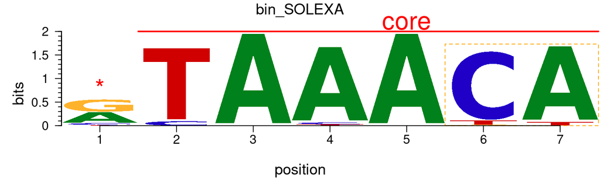

Plot a DNA sequence logo with markers

```r
markerRect <- new("marker", type="rect", start=6, stop=7, gp=gpar(lty=2, fill=NA, col="orange"))
markerLine <- new("marker", type="line", start=2, stop=7, gp=gpar(lwd=2, col="red"))
markerText <- new("marker", type="text", start=c(1, 5),
                  label=c("*", "core"), gp=gpar(cex=2, col="red"))
motif <- new("pcm", mat=as.matrix(pcm), name="bin_SOLEXA",
             markers=c(markerRect, markerLine, markerText))
plot(motif)
```

## change the x-axis labels

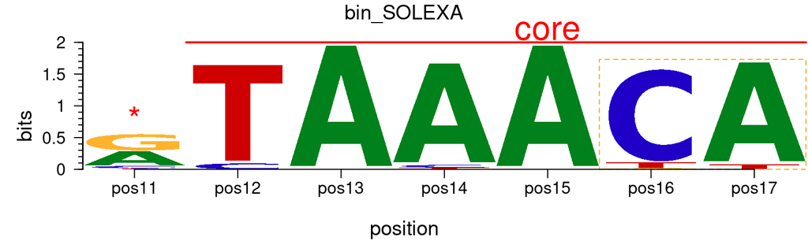

Plot a DNA sequence logo with pre-defined xlabels

```r
plot(motif, xaxis=paste0("pos", seq.int(7)+10))
```

## plot a RNA sequence logo

To plot a RNA sequence logo, you only need to change the rowname of the matrix from “T” to “U” as follows.

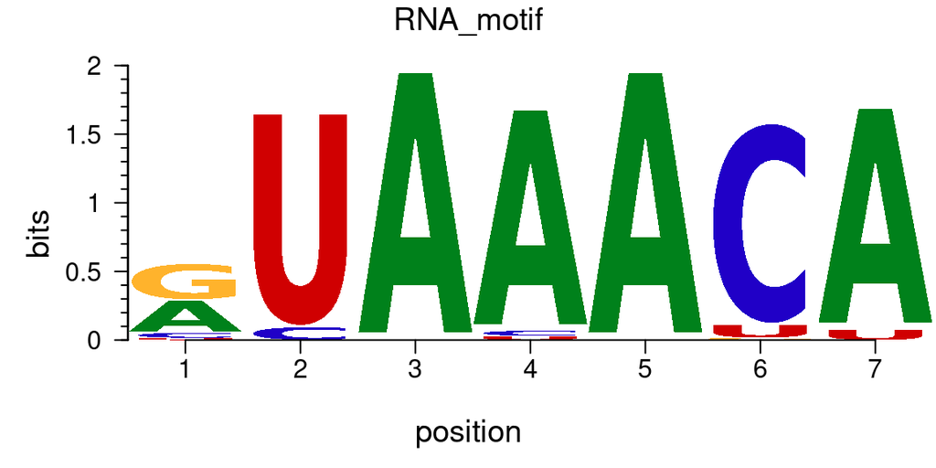

Plot an RNA sequence logo

```r
rna <- pcm
rownames(rna)[4] <- "U"
motif <- new("pcm", mat=as.matrix(rna), name="RNA_motif")
plot(motif)
```

## plot an amino acid sequence logo

Given that motifStack allows to use any letters as symbols, it can also be used to draw amino acid sequence logos.

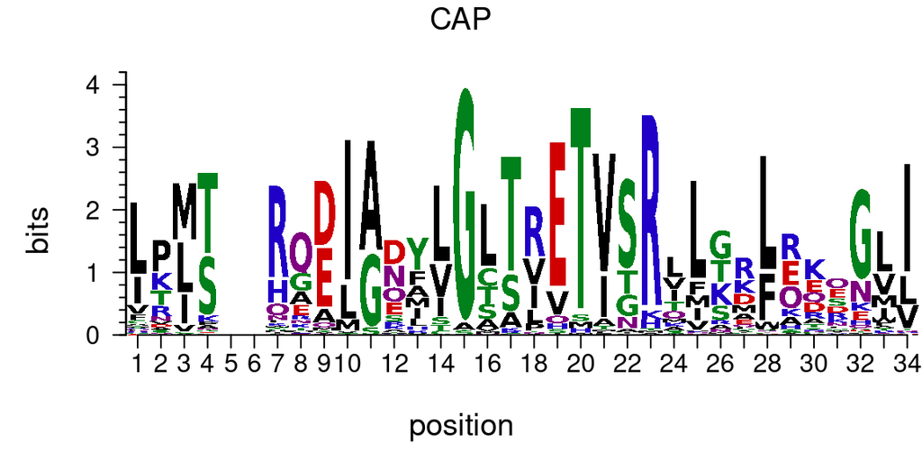

Plot an sequence logo with any symbols as you want such as amino acid sequence logo

```r
library(motifStack)
protein<-read.table(file.path(find.package("motifStack"),"extdata","cap.txt"))
protein<-t(protein[,1:20])
motif<-pcm2pfm(protein)
motif<-new("pfm", mat=motif, name="CAP",
            color=colorset(alphabet="AA",colorScheme="chemistry"))
plot(motif)
```

## plot an affinity logo

It can also be used to draw affinity logos given a position specific affinity matrix (PSAM) as described by Foat et al. <sup>2</sup>.

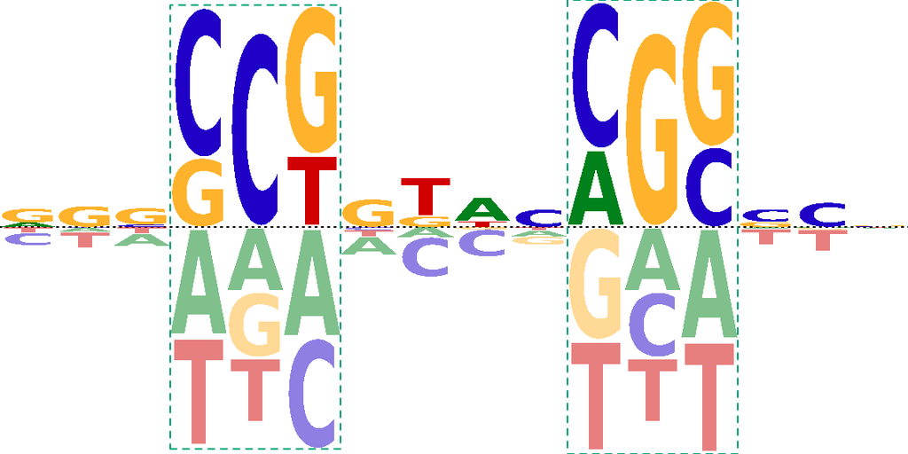

Plot an affinity logo

```r
library(motifStack)
motif<-matrix(
  c(
    .846, .631, .593, .000, .000, .000, .434, .410, 1.00, .655, .284, .000, .000, .771, .640, .961,
    .625, .679, .773, 1.00, 1.00, .000, .573, .238, .397, 1.00, 1.00, .000, .298, 1.00, 1.00, .996,
    1.00, 1.00, 1.00, .228, .000, 1.00, 1.00, .597, .622, .630, .000, 1.00, 1.00, .871, .617, 1.00,
    .701, .513, .658, .000, .000, .247, .542, 1.00, .718, .686, .000, .000, .000, .595, .437, .970
  ), nrow=4, byrow = TRUE)
rownames(motif) <- c("A", "C", "G", "T")
motif<-new("psam", mat=motif, name="affinity logo",
           markers=list(new("marker", type="rect",
                            start=c(4, 11), stop=c(6, 13),
                            gp=gpar(col="#009E73", fill=NA, lty=2))))
plot(motif)
```

## plot sequence logo stack

To show multiple motifs on the same canvas as a sequence logo stack, the distance of motifs need to be calculated first. Previously, MotIV<sup>3</sup>::`motifDistances` ( R implementation of STAMP<sup>4</sup>) is used to calculate the distance. However, The MotIV package were dropped from Bioconductor 3_12. Currently, by default, R implementation of matalign is used. After alignment, users can use `plotMotifLogoStack`, `plotMotifLogoStackWithTree` or `plotMotifStackWithRadialPhylog` to draw sequence logos in different layouts. To make it easy to use, we integrated different functionalities into one workflow function named as `motifStack`.

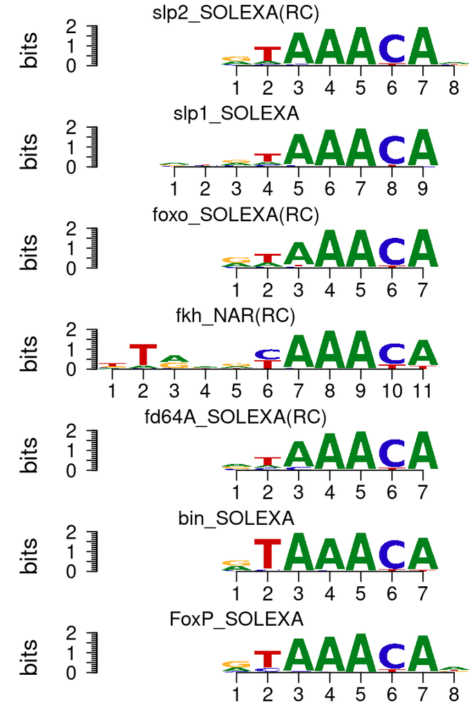

Plot motifs with sequence logo stack style

```r
library(motifStack)
#####Input#####
motifs<-importMatrix(dir(file.path(find.package("motifStack"),
                                   "extdata"),"pcm$",
                         full.names = TRUE))

## plot stacks
motifStack(motifs, layout="stack", ncex=1.0)
```

```r
rnaMotifs <- DNAmotifToRNAmotif(motifs)
names(rnaMotifs)
```

```
## [1] "FoxP_SOLEXA"  "bin_SOLEXA"   "fd64A_SOLEXA" "fkh_NAR"      "foxo_SOLEXA"
## [6] "slp1_SOLEXA"  "slp2_SOLEXA"
```

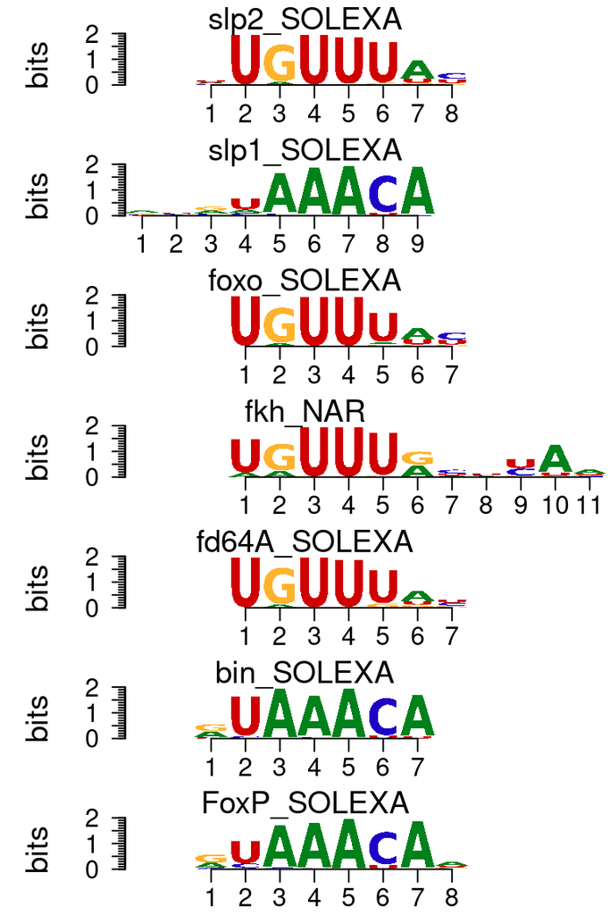

Plot RNA motifs with sequence logo stack style

```r
motifStack(rnaMotifs, layout = "stack",
           reorder=FALSE) ## we can also use reorder=FALSE to keep the order of input.
```

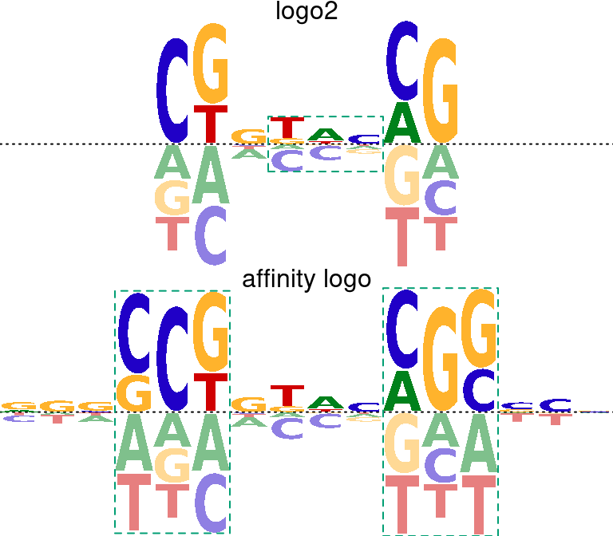

Plot affinity logos with sequence logo stack style

```r
motif2 <- motif
motif2$mat <- motif$mat[, 5:12]
motif2$name <- "logo2"
psamMotifs <- list(motif, motif2)
motifStack(psamMotifs)
```

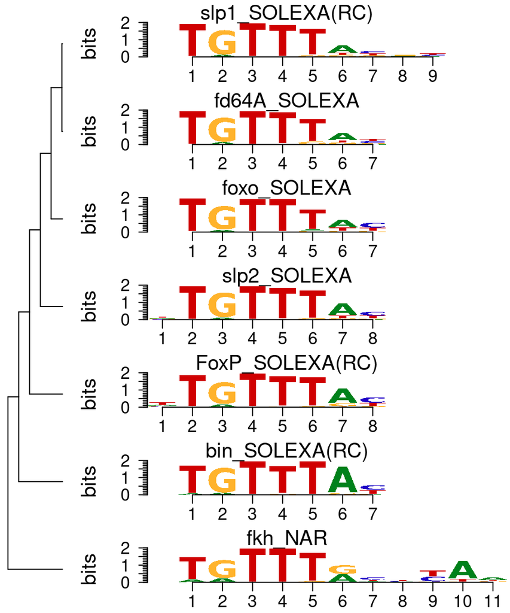

Sequence logo stack with hierarchical cluster tree

```r
## plot stacks with hierarchical tree
motifStack(motifs, layout="tree")
```

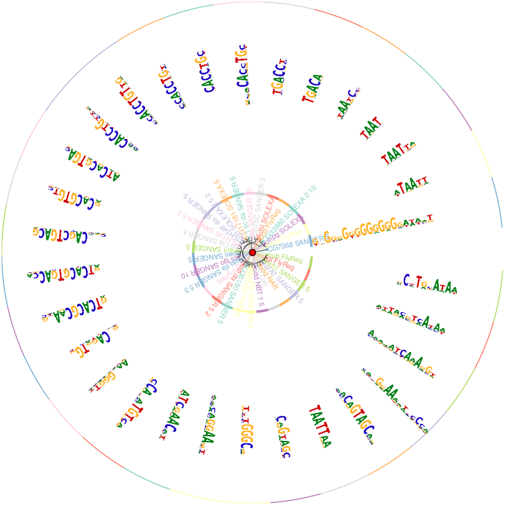

Plot motifs in a radial style when the number of motifs is too much to be shown in a vertical stack

```r
## When the number of motifs is too much to be shown in a vertical stack,
## motifStack can draw them in a radial style.
## random sample from MotifDb
library("MotifDb")
matrix.fly <- query(MotifDb, "Dmelanogaster")
motifs2 <- as.list(matrix.fly)
## use data from FlyFactorSurvey
motifs2 <- motifs2[grepl("Dmelanogaster\\-FlyFactorSurvey\\-",
                         names(motifs2))]
## format the names
names(motifs2) <- gsub("Dmelanogaster_FlyFactorSurvey_", "",
                       gsub("_FBgn\\d+$", "",
                            gsub("[^a-zA-Z0-9]","_",
                                 gsub("(_\\d+)+$", "", names(motifs2)))))
motifs2 <- motifs2[unique(names(motifs2))]
pfms <- sample(motifs2, 30)
## creat a list of object of pfm
motifs2 <- mapply(pfms, names(pfms), FUN=function(.ele, .name){
  new("pfm",mat=.ele, name=.name)}, SIMPLIFY = FALSE)
## trim the motifs
motifs2 <- lapply(motifs2, trimMotif, t=0.4)
## setting colors
library(RColorBrewer)
color <- brewer.pal(10, "Set3")
## plot logo stack with radial style
motifStack(motifs2, layout="radialPhylog",
           circle=0.3, cleaves = 0.2,
           clabel.leaves = 0.5,
           col.bg=rep(color, each=3), col.bg.alpha=0.3,
           col.leaves=rep(color, each=3),
           col.inner.label.circle=rep(color, each=3),
           inner.label.circle.width=0.05,
           col.outer.label.circle=rep(color, each=3),
           outer.label.circle.width=0.02,
           circle.motif=1.2,
           angle=350)
```

## plot a sequence logo cloud

We can also plot a sequence logo cloud for DNA motifs.

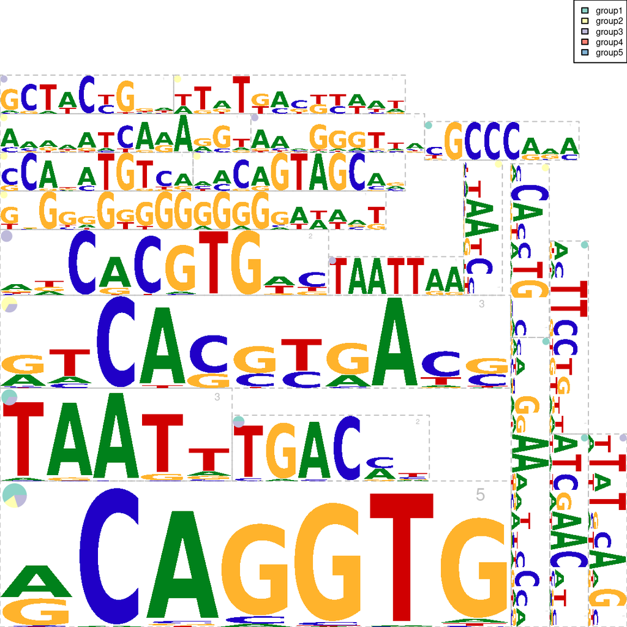

Sequence logo cloud with rectangle packing layout

```r
## assign groups for motifs
groups <- rep(paste("group",1:5,sep=""), each=10)
names(groups) <- names(pfms)
## assign group colors
group.col <- brewer.pal(5, "Set3")
names(group.col)<-paste("group",1:5,sep="")
## create a list of pfm objects
pfms <- mapply(names(pfms), pfms, FUN=function(.ele, .pfm){
  new("pfm",mat=.pfm, name=.ele)}
               ,SIMPLIFY = FALSE)
## use matalign to calculate the distances of motifs
hc <- clusterMotifs(pfms)
## convert the hclust to phylog object
library(ade4)
phylog <- ade4::hclust2phylog(hc)
## reorder the pfms by the order of hclust
leaves <- names(phylog$leaves)
pfms <- pfms[leaves]
## extract the motif signatures
motifSig <- motifSignature(pfms, phylog, cutoffPval=0.0001, min.freq=1)
## draw the motifs with a tag-cloud style.
motifCloud(motifSig, scale=c(6, .5),
           layout="rectangles",
           group.col=group.col,
           groups=groups,
           draw.legend=TRUE)
```

## plot grouped sequence logo

Grouped sequence logo can also be plotted in radial phylogeny tree style.

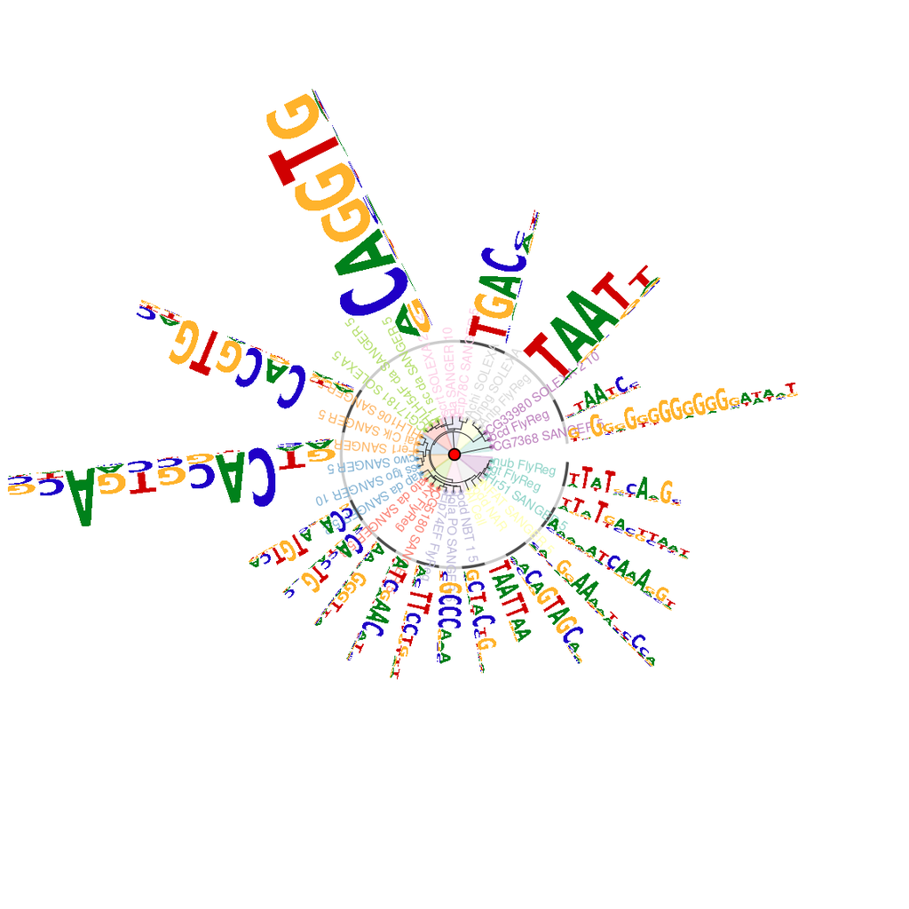

Grouped sequence logo with radialPhylog style layout

```r
## get the signatures from object of motifSignature
sig <- signatures(motifSig)
## set the inner-circle color for each signature
gpCol <- sigColor(motifSig)
## plot the logo stack with radial style.
plotMotifStackWithRadialPhylog(phylog=phylog, pfms=sig,
                              circle=0.4, cleaves = 0.3,
                              clabel.leaves = 0.5,
                              col.bg=rep(color, each=3), col.bg.alpha=0.3,
                              col.leaves=rep(rev(color), each=3),
                              col.inner.label.circle=gpCol,
                              inner.label.circle.width=0.03,
                              angle=350, circle.motif=1.2,
                              motifScale="logarithmic")
```

## motifCircos

We can also plot it with circos style. In circos style, we can plot two group of motifs and with multiple color rings.

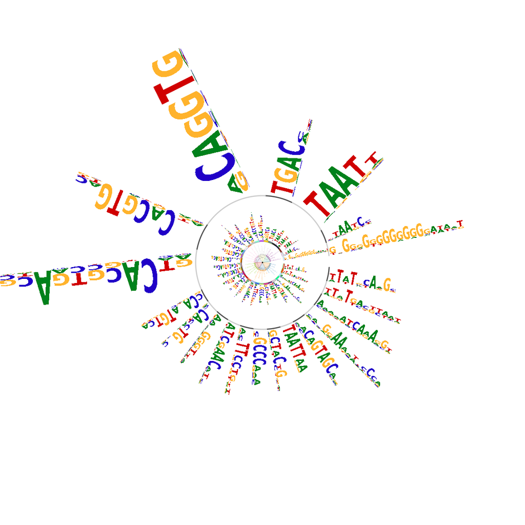

Grouped sequence logo with circos style layout

```r
## plot the logo stack with cirsoc style.
motifCircos(phylog=phylog, pfms=pfms, pfms2=sig,
            col.tree.bg=rep(color, each=5), col.tree.bg.alpha=0.3,
            col.leaves=rep(rev(color), each=5),
            col.inner.label.circle=gpCol,
            inner.label.circle.width=0.03,
            col.outer.label.circle=gpCol,
            outer.label.circle.width=0.03,
            r.rings=c(0.02, 0.03, 0.04),
            col.rings=list(sample(colors(), 30),
                           sample(colors(), 30),
                           sample(colors(), 30)),
            angle=350, motifScale="logarithmic")
```

## motifPiles

We can also plot the motifs in pile style. In pile style, we can plot two group of motifs with multiple types of annotation, for example heatmap. The *col.anno* parameter should be set as a named list.

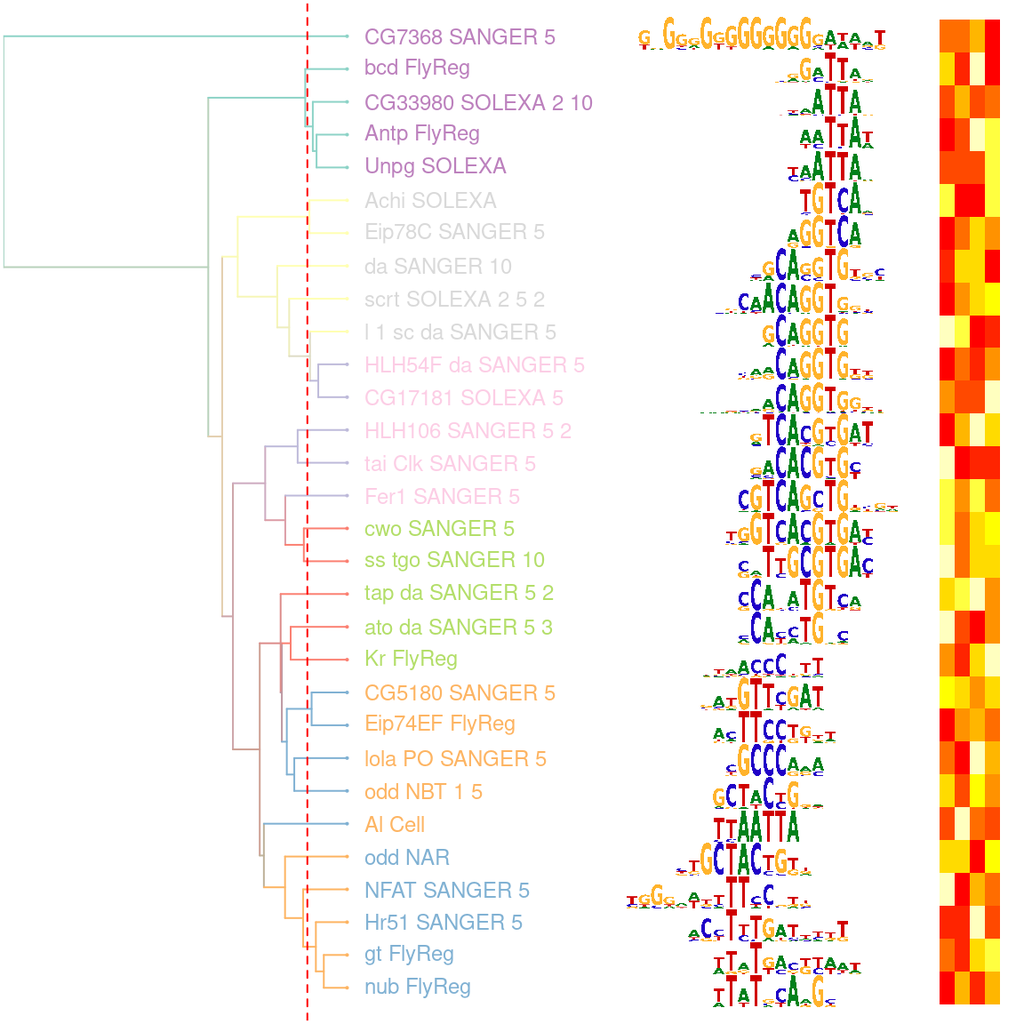

Grouped sequence logo with a heatmap

```r
## plot the logo stack with heatmap.
df <- data.frame(A=runif(n = 30), B=runif(n = 30), C=runif(n = 30), D=runif(n = 30))
map2col <- function(x, pal){
  rg <- range(x)
  pal[findInterval(x, seq(rg[1], rg[2], length.out = length(pal)+1),
                   all.inside = TRUE)]
}
dl <- lapply(df, map2col, pal=heat.colors(10))
## alignment of the pfms, this step will make the motif logos occupy
## more space. Users can skip this alignment to see the difference.
pfmsAligned <- DNAmotifAlignment(pfms)
## plot motifs
motifPiles(phylog=phylog, pfms=pfmsAligned,
            col.tree=rep(color, each=5),
            col.leaves=rep(rev(color), each=5),
            col.pfms2=gpCol,
            r.anno=rep(0.02, length(dl)),
            col.anno=dl,
            motifScale="logarithmic",
            plotIndex=TRUE,
            groupDistance=10)
```

# plot motifs with d3.js

Interactive plot can be generated using `browseMotifs` function which leverages the **d3.js** library. All motifs on the plot are draggable and the plot can be easily exported as a **Scalable Vector Graphics (SVG)** file.

```r
browseMotifs(pfms = pfms, phylog = phylog, layout="tree", yaxis = FALSE, baseWidth=6, baseHeight = 15)
```

[interactive chart not shown]

Plot the motifs in radialPhylog layout.

```r
browseMotifs(pfms = pfms, phylog = phylog, layout="radialPhylog", yaxis = FALSE, xaxis = FALSE, baseWidth=6, baseHeight = 15)
```

[interactive chart not shown]

# docker container for motifStack

[Docker](https://docs.docker.com/) container allows software to be packaged into containers which can be run in any platform using a virtual machine called boot2docker. To ease the installation of motifStack and its depencies, we have created a docker image containing all the components needed to run motifStack. Users can download the [motifStack docker](https://hub.docker.com/r/jianhong/motifstack/) image using the following code snippet.

```
cd ~ ## in windows, please try cd c:\\ Users\\ username
docker pull jianhong/motifstack:latest
mkdir tmp4motifstack ## this will be the share folder for your host and container.
docker run -ti --rm -v ${PWD}/tmp4motifstack:/volume/data jianhong/motifstack:latest bash
  In motifstack:latest docker
    1  cd /volume/data
    2  git clone https://github.com/jianhong/motifStack.documentation.git
    3  cd motifStack.documentation/
    4  cp /usr/bin/matalign app/matalign-v4a
    5  cp /usr/bin/phylip/neighbor app/neighbor.app/Contents/MacOS/neighbor
    6  R cmd -e "rmarkdown::render('suppFigure2.Rmd')"
    7  R cmd -e "rmarkdown::render('suppFigure6.Rmd')"
```

You will see the test.pdf file in the folder of tmp4motifstack.

# plot motifs with ggplot2

motifs could be plotted by `geom_motif` function.

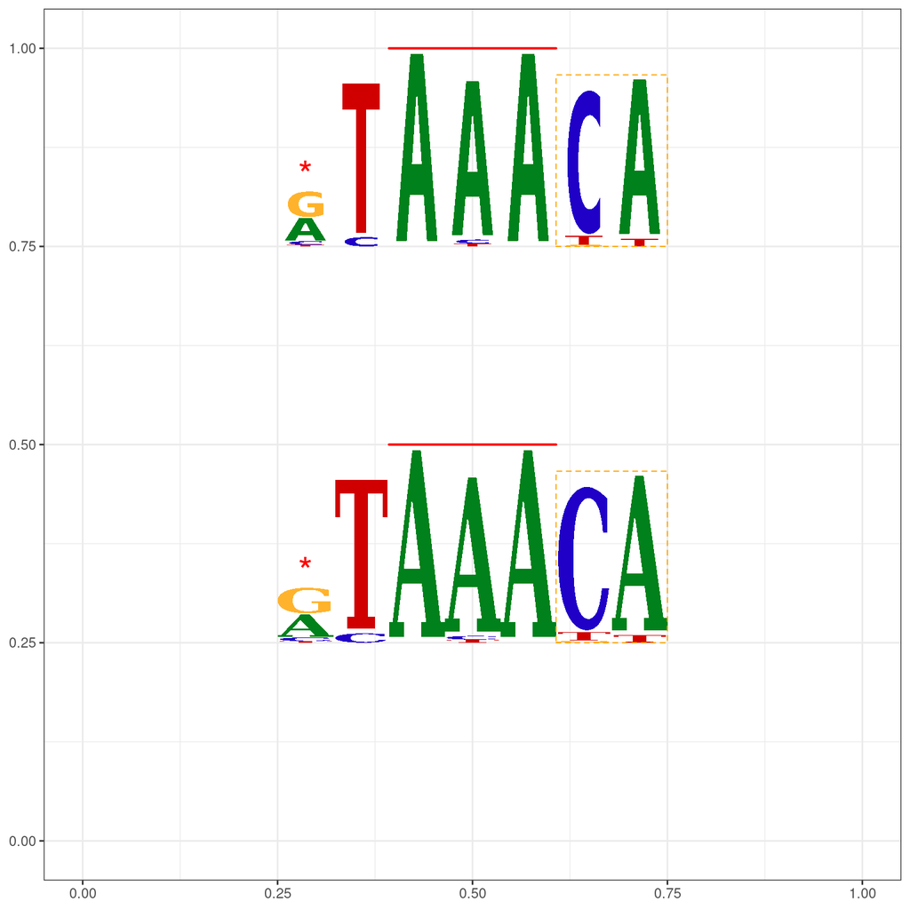

```r
pcm <- read.table(file.path(find.package("motifStack"),
                            "extdata", "bin_SOLEXA.pcm"))
pcm <- pcm[,3:ncol(pcm)]
rownames(pcm) <- c("A","C","G","T")
markerRect <- new("marker", type="rect", start=6, stop=7, gp=gpar(lty=2, fill=NA, col="orange"))
markerLine <- new("marker", type="line", start=3, stop=5, gp=gpar(lwd=2, col="red"))
markerText <- new("marker", type="text", start=1, label="*", gp=gpar(cex=2, col="red"))
motif <- new("pcm", mat=as.matrix(pcm), name="bin_SOLEXA",
             markers=c(markerRect, markerLine, markerText))
pfm <- pcm2pfm(motif)
df <- data.frame(xmin=c(.25, .25), ymin=c(.25, .75), xmax=c(.75, .75), ymax=c(.5, 1),
                 fontfamily=c("serif", "mono"), fontface=c(2, 1))
df$motif <- list(pfm, pfm)

library(ggplot2)

ggplot(df, aes(xmin=xmin, ymin=ymin, xmax=xmax, ymax=ymax, motif=motif,
               fontfamily=fontfamily, fontface=fontface)) +
    geom_motif() + theme_bw() + ylim(0, 1) + xlim(0, 1)
```

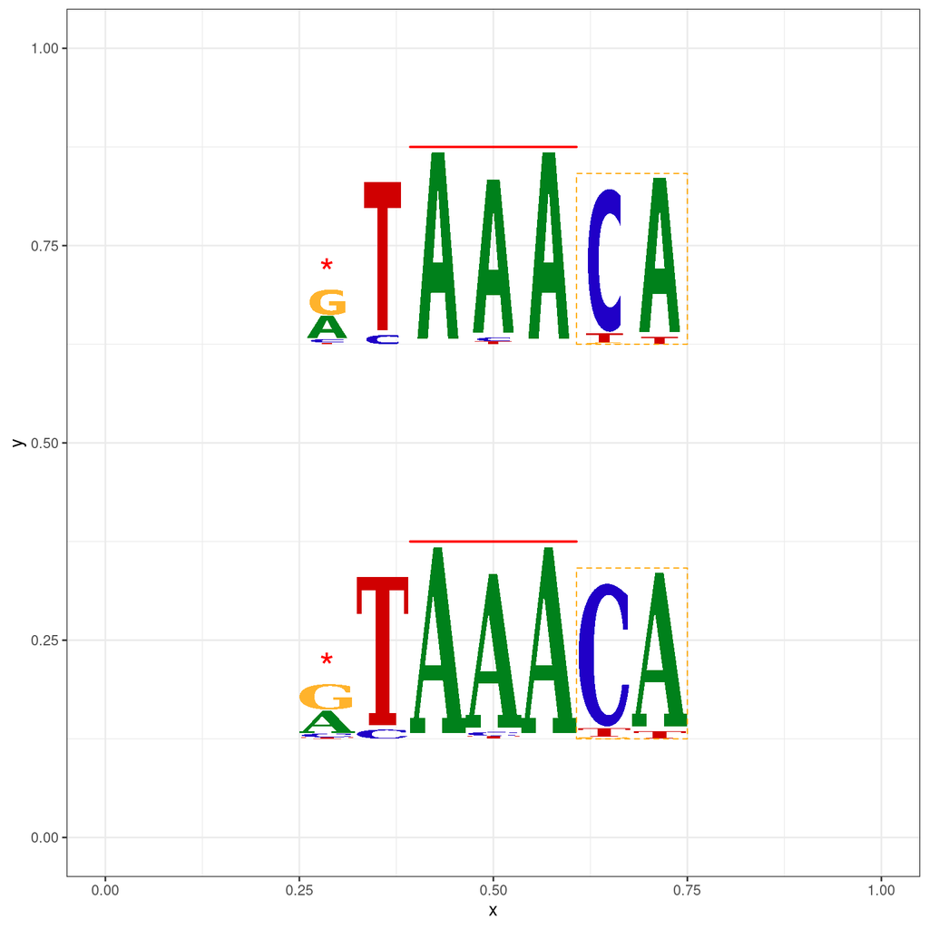

```r
df <- data.frame(x=.5, y=c(.25, .75), width=.5, height=.25,
                 fontfamily=c("serif", "mono"), fontface=c(2, 1))
df$motif <- list(pfm, pfm)

ggplot(df, aes(x=x, y=y, width=width, height=height, motif=motif,
               fontfamily=fontfamily, fontface=fontface)) +
    geom_motif(use.xy=TRUE) + theme_bw() + ylim(0, 1) + xlim(0, 1)
```

# Reference

1. Bembom, O. SeqLogo: Sequence logos for dna sequence alignments. *R package version 1.5.4* (2006).

2. Foat, B. C., Morozov, A. V. & Bussemaker, H. J. Statistical mechanical modeling of genome-wide transcription factor occupancy data by matrixreduce. *Bioinformatics* **22,** e141–e149 (2006).

3. Mercier, E. & Gottardo, R. MotIV: Motif identification and validation. *R package version 1.10.0* (2010).

4. S, M. & PV, B. STAMP: A web tool for exploring dna-binding motif similarities. *Nucleic Acids Res.* **35(Web Server issue),** W253–W258 (2007).